# 2 ビューツリー

ビューツリーはSwiftUIを理解する上で最も基本的で重要な概念である。ビューツリーを理解することで、SwiftUIがどのように画面を描画しているのかを理解することができる。 そもそもビューツリーとは「UIの設計図」であり、レンダリングされるたびに別のビューツリーが生成されるようになっている。

**ノート**

要するに、開発者が「こういうレイアウトにして」とSwiftUIに伝えるための一時的な指示書のようなものである。

例として、以下の2つを見ていく。

**① 余白を作ってから色を塗る**

コード

```
ContentView.swift
```

```
import SwiftUI

struct ContentView: View {
    var body: some View {
        Text("Hello")
            .padding()
            .background(Color.blue)
        }
}

#Preview {
    ContentView()
}
```

ビューツリー

```
.background
 ├── .padding
 │   └── Text
 └── Color
```

描画結果

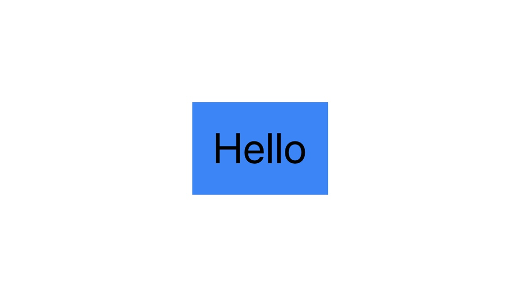

**② 色を塗ってから余白を作る**

コード

```
ContentView.swift
```

```
import SwiftUI

struct ContentView: View {
    var body: some View {
        Text("Hello")
            .background(Color.blue)
            .padding()
        }
}

#Preview {
    ContentView()
}
```

ビューツリー

```
.padding
 └── .background
     ├── Text
     └── Color
```

描画結果

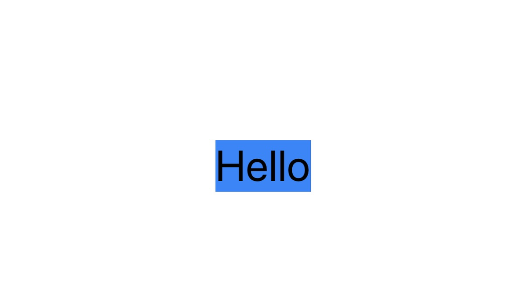

ビューツリーは、実際のコードのモディファイア[^1]の連なりを**下から上**に解釈する。①の場合で言うと、`Text`が`.padding`や`.background`にどんどん包まれていくイメージである。上の2つの例から`.padding()`と`.background()`を入れ替えただけでも、描画結果のようにUIに差異が生じてくるのがわかるだろう。このように、モディファイアを適用する順序によって構築されるビューツリーの親子関係（階層構造）が変わり、UIの描画結果も変化する。

意図通りのレイアウトや装飾を実現するためには、単にモディファイアを並べるのではなく、**モディファイアによってどのようなビューツリーが構築されているのか**を常に意識することが重要である。

## 2.1 ビュービルダー

上の例では1つのビュー[^2]のみの場合だったが、2つ以上ある場合は**ビュービルダー**という構文が使われる。

コード

```
ContentView.swift
```

```
import SwiftUI

struct ContentView: View {
    var body: some View {
        HStack {
            Image(systemName: "hand.wave")
            Text("Hello")
        }
    }
}

#Preview {
    ContentView()
}
```

ビューツリー

```
HStack
 ├── Image
 └── Text
```

描画結果

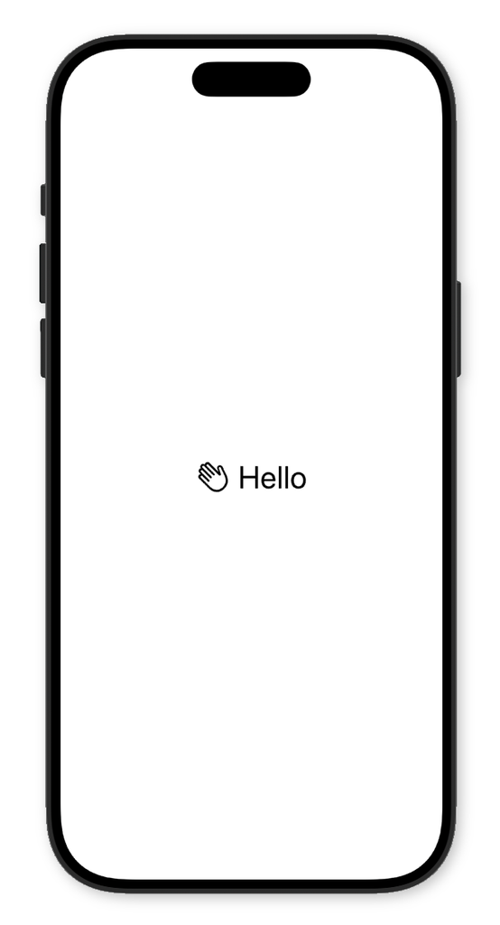

上の例でいう、`HStack { ... }`の`{ ... }`の部分がビュービルダーである。この構文は各ビューを**リスト**として扱っている。

**ノート**

`HStack`は**コンテナビュー**と呼ばれる。詳しくは第4章で学ぶ。

`{ ... }`の部分は少し特殊であり、Swiftにおいて**クロージャ**[^3]として扱われる。さらにこのクロージャには`@ViewBuilder`という属性（アトリビュート）がついているので、各ビューをカンマ（`,`）で区切ることなく、体系的にビューを記述できる。

**ヒント**

`@ViewBuilder`の定義部分は以下のようになっている。

```
Swift
```

```
extension ViewBuilder {
  public static func buildBlock<C0, C1>(_ c0: C0, _ c1: C1) -> TupleView<(C0, C1)> where C0 : View, C1 : View
}
```

もし、ビュービルダーを使わなかったら、以下のように配列としてパラメータ関数に格納して渡す形なるだろう。

```
Swift
```

```
HStack(views: [
    Image(systemName: "hand.wave"),
    Text("Hello")
])
```

SwiftUIでは複数のビューを組み合わせるコンテナビューが頻繁に使われるが、その都度引数として配列を渡す設計では、コードの肥大化や可読性の低下を招いてしまう。ビュービルダーは、並べられた複数のビューを裏側で**タプルビュー**[^4]としてまとめ上げ、コンテナビューへ渡すことで、直感的で宣言的なコード記述を可能にしている。

### 2.1.1 サブビュー

ビュービルダーをさらに理解するために、さらにコードを拡張した例を見ていく。

コード

```
ContentView.swift
```

```
import SwiftUI

struct ContentView: View {
    var body: some View {
        HStack(spacing: 20) {
            Image(systemName: "hand.wave")
            Text("Hello")
            Spacer()
            Text("And Goodbye!")
            Image(systemName: "hand.wave")
        }
    }
}

#Preview {
    ContentView()
}
```

ビューツリー

```
HStack
 ├── Image
 ├── Text
 ├── Spacer
 ├── Text
 └── Image
```

描画結果

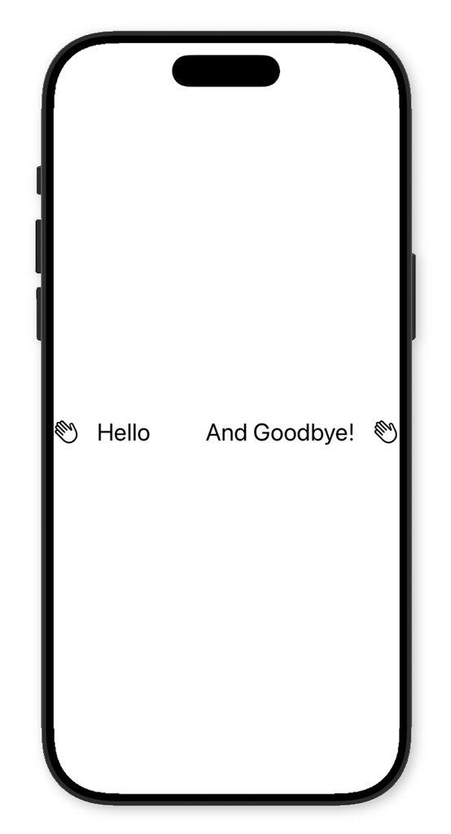

現在の画面には5つのビューが並んでおり、これらはHStackの内部で展開されて表示されている。ただ、画面が複雑になってビューの数が増えると、コードが一気に肥大化して構造を追うのが難しくなってしまう。そこで、まとまりごとに**サブビュー**として切り出せば、余計なレイアウト階層を増やさずにコードの見通しを良くできる。

```
Swift
```

```
struct ContentView: View {
    @ViewBuilder var hello: some View {
        Image(systemName: "hand.wave")
        Text("Hello")
    }
    @ViewBuilder var bye: some View {
        Text("And Goodbye!")
        Image(systemName: "hand.wave")
    }
    var body: some View {
        HStack(spacing: 20) {
            hello
            Spacer()
            bye
        }
    }
}
```

### 2.1.2 タプルビューの透過性

コンポーネントの定義時に`@ViewBuilder`を付加することで、複数のビューを含むコンポーネントを定義することができる。

ここで最も重要な原則は、「`@ViewBuilder`によって作られたタプルビューは、**レイアウト上いかなるノード（境界や枠）も新しく生み出さない**」という点にある。

**ヒントサブビューに分割してもレイアウトが崩れない理由**

通常のUIフレームワーク（UIKitの `UIView` やHTMLの `<div>` など）では、コードをまとめようとして新しいコンテナやタグを挟むと、それがそのまま画面上の「階層（親ノード）」として追加されてしまう。その結果、意図しない余白やレイアウトのズレが生じることが多い。

しかし、SwiftUIにおけるタプルビューは完全に透明な入れ物として設計されている。複数のビューをSwiftの型システム上で**「1つの戻り値」として運ぶためだけの仮の小包**であり、レイアウトエンジンが評価する段階では、その小包の存在感はゼロになる。

開発者がコードを書くとき、`HStack`の直下には3つの要素が渡されているように見える。

```
人間からの見え方
```

```
hello   <- サブビュー
Spacer()
bye     <- サブビュー
```

だが、SwiftUIがレイアウトを計算する際、`hello`と`bye`の中身を包んでいるタプルビューは完全に展開される。親である`HStack`から見ると、最初から以下のように5つの要素がフラットに並んでいる状態として認識される。

```
コンピュータからの見え方
```

```
Image(systemName: "hand.wave")
Text("Hello")

Spacer()

Text("And Goodbye!")
Image(systemName: "hand.wave")
```

この仕組みのおかげで、コードをいくらサブビューに切り出しても、画面の配置や余白が崩れる心配はない。HTMLの`<div>`のように余計な枠組みが勝手に増えて、意図せぬUIの崩れが起きることもない。実際、`HStack`の`spacing: 20`は画像とテキストの間にもしっかり効いている。見た目への影響を一切気にせず、純粋にコードの読みやすさのためだけに部品を小分けにできるのが大きなメリットである。我々開発者は、UIの崩れを気にせず、ただコードを読みやすくするために容易にサブビューを使うことができるのだ。

[^1]: **モディファイア**とは、SwiftUIでビューの見た目や配置、挙動を変更・装飾するためのメソッドのこと。WebアプリにおけるCSSやJavaScriptにあたる。`.padding()`や`.background()`、`.border()`などのように、ビューの後ろにドットでつなげて呼び出す。
[^2]: SwiftUIでは、ReactやHTMLでいう「要素」のことを**ビュー**と呼ぶ。
[^3]: **クロージャ**とは、処理そのものを変数や引数として手渡せる「名前のない関数」のこと。JavaScriptにおけるコールバック関数やアロー関数（`() => {}`のような記法）と同じ立ち位置。
[^4]: **タプルビュー**とは、複数のビューを1つのビューとしてまとめたもの。